# PML - Assignment

JND

1 May 2017

## Study Background

In this study, the goal is to investigate how well an activity was performed by six wearers of electronic devices. They were asked to perform one set of 10 repetitions of the Unilateral Dumbbell Biceps Curl in five different fashions, namely

Class A: exactly according to the specification Class B: throwing the elbows to the front Class C: lifting the dumbbell only halfway Class D: lowering the dumbbell only half way Class E: throwing the hips to the front. Notice that only class A corresponds to the specified execution of the exercise, and others correspond to common mistakes. To ensure the quality of data, an experienced weight lifter was there to supervise the participants. More information is available from the website here.

## Project Goal

The goal of this project is to predict the manner in which the participants did the exercise.

## Data Processing

```r
## Load packages necessary
library(caret)
library(randomForest)
library(rpart)
library(RGtk2)
library(rattle)
```

```r
library(rpart.plot)
library(repmis)



## set directory
setwd("C:/Users/Niki/Desktop/pml")
training <- read.csv("pml-training.csv", na.strings = c("NA", ""))
testing <- read.csv("pml-testing.csv", na.strings = c("NA", ""))
```

## Data Cleaning

```r
#We now delete columns (predictors) of the training set that contain any missing values.

training <- training[, colSums(is.na(training)) == 0]
testing <- testing[, colSums(is.na(testing)) == 0]

#We also remove the first seven predictors since these variables have little predicting power for the outcome classe.

trainData <- training[, -c(1:7)]
testData <- testing[, -c(1:7)]
```

## Data Splitting

```r
set.seed(4447)
inTrain <- createDataPartition(trainData$classe, p = 0.7, list = FALSE)
train <- trainData[inTrain, ]
valid <- trainData[-inTrain, ]
```

# Prediction Algorithms

We use classification trees and random forests to predict the outcome.

# Classification trees

Here we consider 10-fold cross validation.

```r
control <- trainControl(method = "cv", number = 10)
fit_rpart <- train(classe ~ ., data = train, method = "rpart",
                   trControl = control)
print(fit_rpart)
```

```
## CART
##
## 13737 samples
##    52 predictor
##     5 classes: 'A', 'B', 'C', 'D', 'E'
##
## No pre-processing
## Resampling: Cross-Validated (10 fold)
## Summary of sample sizes: 12365, 12365, 12363, 12364, 12362, 12362, ...
## Resampling results across tuning parameters:
##
##   cp          Accuracy   Kappa
##   0.03397416  0.5033852  0.35173348
##   0.05930221  0.4136099  0.20584726
##   0.11504425  0.3315098  0.07185016
##
## Accuracy was used to select the optimal model using  the largest value.
## The final value used for the model was cp = 0.03397416.
```

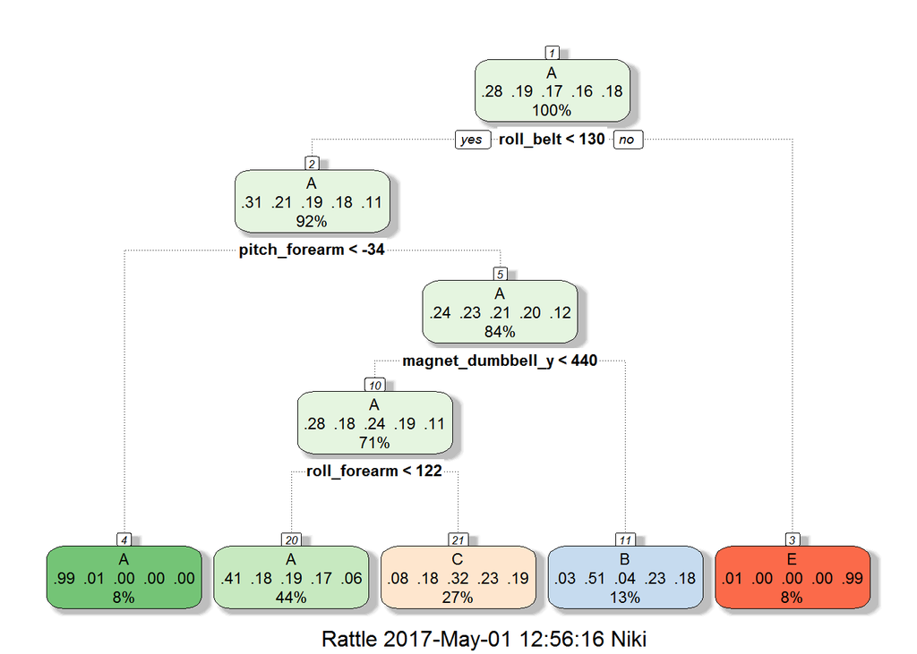

```r
fancyRpartPlot(fit_rpart$finalModel)
```

```r
# predict outcomes using validation set
predict_rpart <- predict(fit_rpart, valid)
# Show prediction result
(conf_rpart <- confusionMatrix(valid$classe, predict_rpart))
```

```
## Confusion Matrix and Statistics
##
##           Reference
## Prediction    A    B    C    D    E
##          A 1530   21  122    0    1
##          B  471  379  289    0    0
##          C  457   31  538    0    0
##          D  439  159  366    0    0
##          E  169  158  268    0  487
##
## Overall Statistics
##
##                Accuracy : 0.4986
##                  95% CI : (0.4857, 0.5114)
##     No Information Rate : 0.521
##     P-Value [Acc > NIR] : 0.9997
##
##                   Kappa : 0.3446
##  Mcnemar's Test P-Value : NA
##
## Statistics by Class:
##
##                      Class: A Class: B Class: C Class: D Class: E
## Sensitivity            0.4990   0.5067  0.33986       NA  0.99795
## Specificity            0.9489   0.8521  0.88656   0.8362  0.88975
## Pos Pred Value         0.9140   0.3327  0.52437       NA  0.45009
## Neg Pred Value         0.6352   0.9223  0.78494       NA  0.99979
## Prevalence             0.5210   0.1271  0.26899   0.0000  0.08292
## Detection Rate         0.2600   0.0644  0.09142   0.0000  0.08275
## Detection Prevalence   0.2845   0.1935  0.17434   0.1638  0.18386
## Balanced Accuracy      0.7240   0.6794  0.61321       NA  0.94385
```

```r
(accuracy_rpart <- conf_rpart$overall[1])
```

```
##  Accuracy
## 0.4985556
```

From the confusion matrix, the accuracy rate is approx 0.5 (0.498), and so the out-of-sample error rate is 0.5. Using classification tree does not predict the outcome classe very well.

## Random forests

Since classification tree method does not perform well, we try random forest method instead.

```r
fit_rf <- randomForest(classe ~pitch_forearm+magnet_arm_x+accel_arm_x+  total_accel_forearm+magnet_dumbbell_z+accel_dumbbell_x, data=train)
print(fit_rf)
```

```
##
## Call:
##  randomForest(formula = classe ~ pitch_forearm + magnet_arm_x +      accel_arm_x + total_accel_forearm + magnet_dumbbell_z + accel_dumbbell_x,      data = train)
##                Type of random forest: classification
##                      Number of trees: 500
## No. of variables tried at each split: 2
##
##         OOB estimate of  error rate: 11.13%
## Confusion matrix:
##      A    B    C    D    E class.error
## A 3663   65   67   88   23  0.06221198
## B  142 2292   94   52   78  0.13769752
## C   72   77 2141   57   49  0.10642738
## D   38   29  134 1961   90  0.12921847
## E   47  115   86  126 2151  0.14811881
```

```r
# predict outcomes using validation set
predict_rf <- predict(fit_rf, valid)
# Show prediction result
(conf_rf <- confusionMatrix(valid$classe, predict_rf))
```

```
## Confusion Matrix and Statistics
##
##           Reference
## Prediction    A    B    C    D    E
##          A 1564   21   32   49    8
##          B   56  954   49   33   47
##          C   30   37  921   22   16
##          D   13   13   54  838   46
##          E   20   56   28   52  926
##
## Overall Statistics
##
##                Accuracy : 0.8841
##                  95% CI : (0.8757, 0.8922)
##     No Information Rate : 0.286
##     P-Value [Acc > NIR] : < 2.2e-16
##
##                   Kappa : 0.8534
##  Mcnemar's Test P-Value : 3.897e-11
##
## Statistics by Class:
##
##                      Class: A Class: B Class: C Class: D Class: E
## Sensitivity            0.9293   0.8825   0.8496   0.8431   0.8878
## Specificity            0.9738   0.9615   0.9781   0.9742   0.9678
## Pos Pred Value         0.9343   0.8376   0.8977   0.8693   0.8558
## Neg Pred Value         0.9717   0.9732   0.9665   0.9683   0.9756
## Prevalence             0.2860   0.1837   0.1842   0.1689   0.1772
## Detection Rate         0.2658   0.1621   0.1565   0.1424   0.1573
## Detection Prevalence   0.2845   0.1935   0.1743   0.1638   0.1839
## Balanced Accuracy      0.9516   0.9220   0.9139   0.9086   0.9278
```

```r
(accuracy_rf <- conf_rf$overall[1])
```

```
##  Accuracy
## 0.8841121
```

For this dataset, random forest method is way better than classification tree method. The accuracy rate is 0.884, and so the out-of-sample error rate is 0.116.

## Prediction on Testing Set

We now use random forests to predict the outcome variable classe for the testing set.

```r
(predict(fit_rf, testData))
```

```
##  1  2  3  4  5  6  7  8  9 10 11 12 13 14 15 16 17 18 19 20
##  B  A  B  A  A  E  D  B  A  A  B  C  B  A  E  E  A  B  B  B
## Levels: A B C D E
```